# Time series

Zhejia Dong

2023-03-10

## Covariate time series

Let $Y = \{Y_t\}$ be time series of response variable and $X = \{X_t\}$ be the covariate time series. The $\gamma_{t,s} (X,Y) = Cov(X_t, Y _s)$ is the cross-variance function for each pairs of t and s.

For jointly stationary process, the cross-correlation function at lag k is $\rho_{k} (X,Y) =Corr(X_t, Y_{t-k}) = Corr(X_{t+k}, Y_t)$ If $X = Y$, then the cross-correlation becomes the autocorrelation of $Y$ at lag k. The coefficient $\rho_0(Y,X)$ measures the contemporaneous *linear association* between $X$ and $Y$. The coefficient $\rho_k (X,Y)$ measures the linear association between $X_t$ and $Y_{t-k}$.

## Sample cross-correlation function

$$Y_t = \beta_0 + \beta_1 X_{t-d} +
e_t$$

$$r_k(X,Y) = \dfrac{\sum(X_t - \bar
X)(Y_{t-k} - \bar Y)}{\sqrt{\sum(X_t - \bar X)^2}\sqrt{\sum(Y_t - \bar
Y)^2}}$$

## Exhibit 11.14

Monthly milk production and the logarithms of monthly electricity production in the United States from January 1994 to December 2005.

- observed both increasing trends

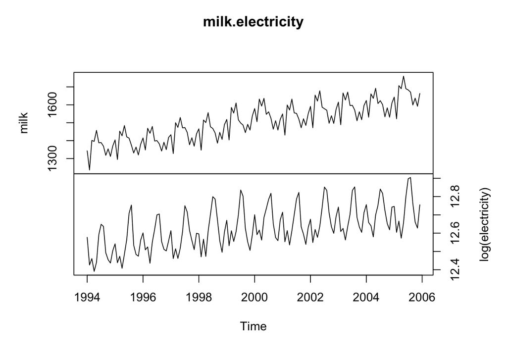

```r
data(milk)
data(electricity)
milk.electricity=ts.intersect(milk,log(electricity))
# ts.intersect merge several time series into a panel of time
plot(milk.electricity,yax.flip=T)
```

- Strong cross-correlation

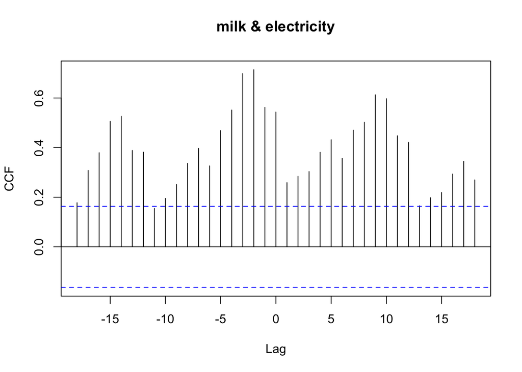

```r
ccf(as.numeric(milk.electricity[,1]),as.numeric(milk.electricity[,2]),
    main='milk & electricity',ylab='CCF')
```

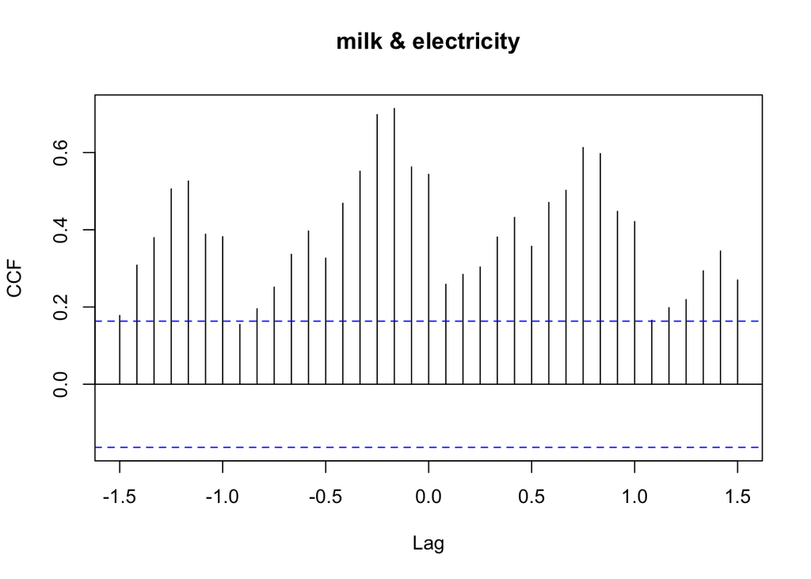

```r
ccf((milk.electricity[,1]),(milk.electricity[,2]), main='milk & electricity',ylab='CCF')
```

## Prewhitening

- Linear operation

$$\tilde X = (1- \pi_1 B - \pi_2 B^2 - \cdots)X_t = \pi(B) X_t$$

- Regression model

$$Y_t = \sum^{+\infty}_{ j = -\infty}\beta_j X_{t-j} + Z_t$$
$$\tilde Y_t = \sum^{+\infty}_{ k = -\infty}\beta_k \tilde X_{t-k} +
\tilde Z_t$$

$\tilde X$ is then a white noise and independent of $\tilde Z$.

- Prewhiten to deal with the spurious correlation.
  - Determine a time series model for the x-variable and store the residuals from this model.
  - Filter the y-variable series using the x-variable model (using the estimated coefficients from step 1). In this step we find differences between observed y-values and “estimated” y-values based on the x-variable model.
  - Examine the CCF between the residuals from Step 1 and the filtered y-values from Step 2. This CCF can be used to identify the possible terms for a lagged regression.

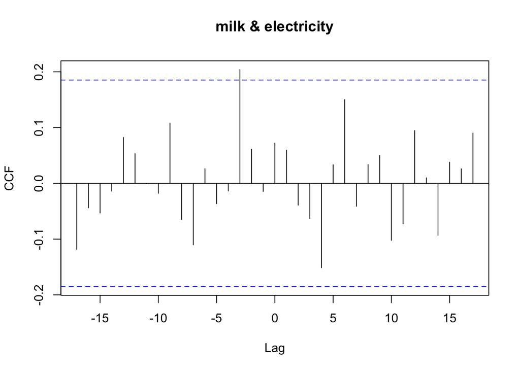

```r
me.dif=ts.intersect(diff(diff(milk,12)),diff(diff(log(electricity),12)))
prewhiten(as.numeric(me.dif[,1]),as.numeric(me.dif[,2]), main='milk & electricity',ylab='CCF' )
```

### Prewhiten simulation

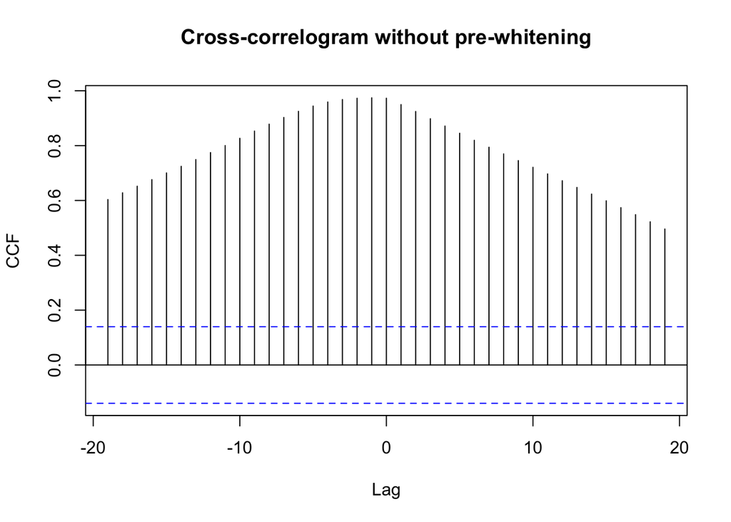

```r
x = arima.sim(list(order = c(1,1,0), ar = 0.7), n = 200)


#Creates a matrix z with columns, xt, xt-3, and xt-4
z = ts.intersect(x, stats::lag(x,-3), stats::lag(x,-4))

#Creates y (our target) from lags 3 and 4 of randomly generated x
y = 15+0.8*z[,2]+1.5*z[,3]

#CCF between x and y doesn't show any relationship
ccf(z[,1],y,na.action = na.omit,main='Cross-correlogram without pre-whitening', ylab = "CCF")
```

```r
aa=auto.arima(x)

coef(aa)
```

```
##       ar1
## 0.7283642
```

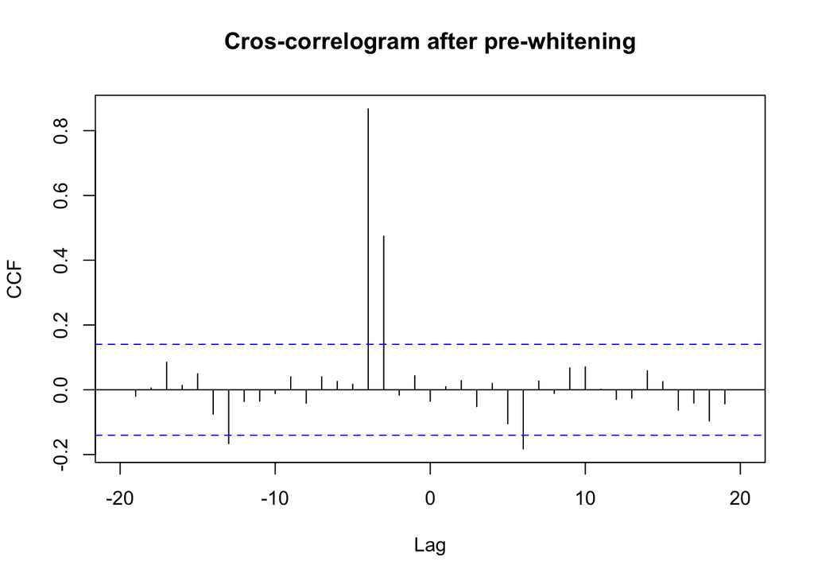

```r
pwx=aa$residuals

#pre-whitening y
newpwy = stats::filter(y, c(1,-(1+coef(aa)[1]),coef(aa)[1]), sides =1)
ccf(pwx,newpwy,na.action=na.omit,main='Cros-correlogram after pre-whitening',xlim=c(-20,20), ylab = "CCF")
```

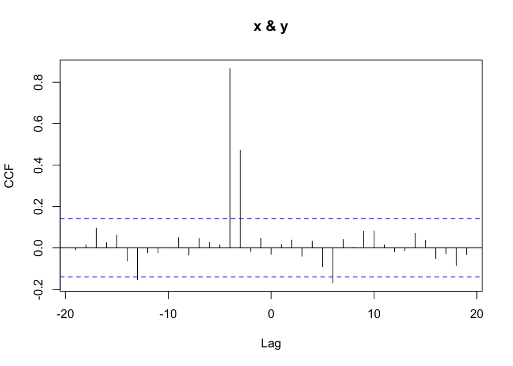

```r
prewhiten(x,y, ylab = "CCF") # prewhiten function fron TSA (the package corrosponding to the textbook)
```